# Reproducible Research: Peer Assessment 1

```r
library(dplyr)
library(lubridate)
```

## Loading and preprocessing the data

Loading data

```r
unzip("activity.zip", list=TRUE)
```

```
##           Name Length                Date
## 1 activity.csv 350829 2014-02-11 10:08:00
```

```r
activity <- read.csv(unzip("activity.zip", "activity.csv"))
head(activity, 2)
```

```
##   steps       date interval
## 1    NA 2012-10-01        0
## 2    NA 2012-10-01        5
```

Convert integer format of variable **interval** to H:Min format

```r
activity$interval <- hm(paste(as.character(activity$interval%/%100),
            ":", as.character(activity$interval%%100), sep=""))
head(activity, 2)
```

```
##   steps       date interval
## 1    NA 2012-10-01       0S
## 2    NA 2012-10-01    5M 0S
```

## What is mean total number of steps taken per day?

Calculate the total number of steps taken per day

```r
day.steps <- activity %>% filter(!is.na(steps))%>% group_by(date) %>%
    summarise(steps=sum(steps))
```

Make a histogram of the total number of steps taken per day

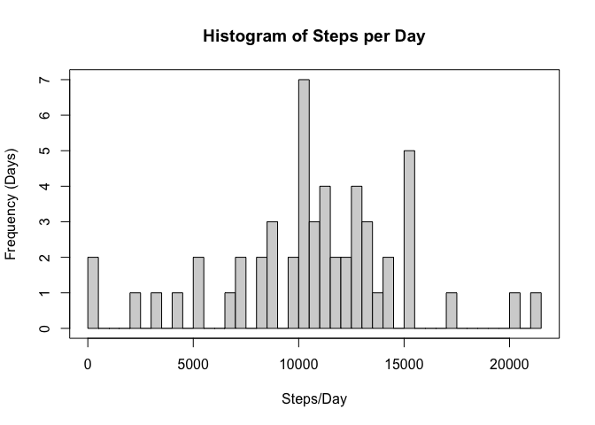

```r
hist(day.steps$steps, breaks=length(day.steps$date),
     main="Histogram of Steps per Day", xlab= "Steps/Day", ylab="Frequency (Days)")
box()
```

Calculate the mean and median of the total number of steps taken per day

```r
day.steps.mean <- as.integer(mean(day.steps$steps))
day.steps.median <- as.integer(median(day.steps$steps))
```

The mean of total steps taken per day is **10766**. Its median is **10765**.

## What is the average daily activity pattern?

Calculate average steps taken in 5-minute interval each day

```r
act.pattern <- activity %>% filter(!is.na(steps))%>% group_by(interval) %>%
    summarise(steps=mean(steps))
```

Make a time series plot of the average steps taken each day based on 5-minute interval

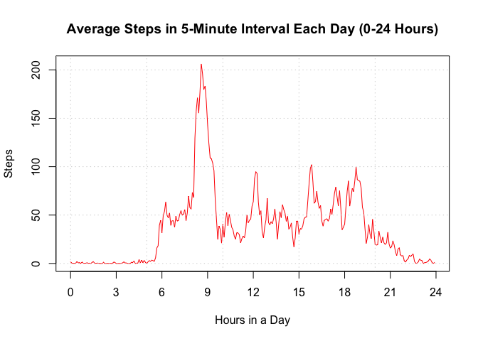

```r
plot(as.numeric(act.pattern$interval)/3600, act.pattern$steps, type="l",
     col="red", main="Average Steps in 5-Minute Interval Each Day (0-24 Hours)",
     xlab="Hours in a Day", ylab="Steps", xaxt="none")
grid()
axis(1,seq(0,24,3))
```

Calculate which 5-minute interval contains the maximum number of steps.

```r
act.pattern.max <- act.pattern[act.pattern$steps==max(act.pattern$steps),]
time <- paste(act.pattern.max$interval@hour,"H:",
              (act.pattern.max$interval@minute-5), "Min to ",
              act.pattern.max$interval@hour,"H:",
              (act.pattern.max$interval@minute), "Min", sep="")
steps <- as.integer(act.pattern.max$steps)
```

Averagingly, at this time period **8H:30Min to 8H:35Min** each day, the activity has the maximum number of steps. It is **206** steps.

## Imputing missing values

Calculate the total number of missing values in the dataset

```r
number.NA <- activity %>% filter(is.na(steps))%>% nrow()
```

The total number of missing value is **2304**.

Create new dataset and filling in all missing values with the mean of steps in that 5-minute interval.

```r
act.modified <- activity
for (i in 1:nrow(act.modified)) {
    if(is.na(act.modified$steps[i])) {
        act.modified$steps[i] <-
        mean(act.modified$steps[act.modified$interval==act.modified$interval[i]],
            na.rm = TRUE)
    }
}
```

Re-calculate the total number of steps taken per day (averaged over two months)

```r
day.steps.2 <- act.modified %>% group_by(date) %>% summarise(steps=sum(steps))
```

Make another histogram of the total number of steps taken each day based on modified data

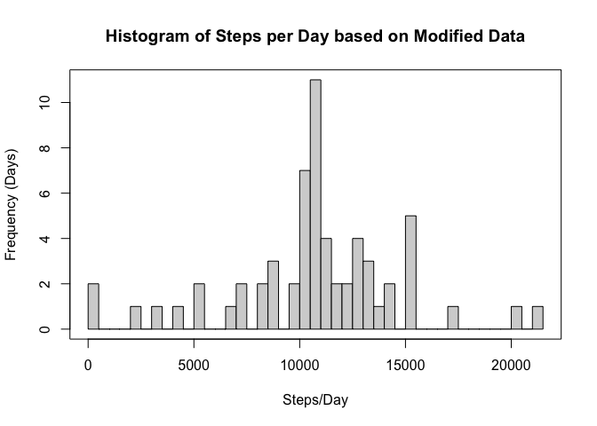

```r
hist(day.steps.2$steps, breaks=length(day.steps.2$date),
     main="Histogram of Steps per Day based on Modified Data",
     xlab= "Steps/Day", ylab="Frequency (Days)")
box()
```

Re-calculate the mean and median of the total number of steps taken per day

```r
day.steps.2.mean=as.integer(mean(day.steps.2$steps))
day.steps.2.median=as.integer(median(day.steps.2$steps))
```

Since we used the average steps of 5-minutes interval in a day to replace those missing data in the same time period, the mean of steps per day doesn’t change (**10766** from modified dataset vs **10766** from original dataset), but its median from modified dataset will be the same of its current mean (**10766** from modified dataset vs **10765** from original dataset).

## Are there differences in activity patterns between weekdays and weekends?

Create a new factor variable **Weekdays** in the dataset with two levels – “weekday” and “weekend”

```r
wd <- c("Monday", "Tuesday", "Wednesday", "Thursday", "Friday")
we <- c("Saturday", "Sunday")
act.modified <- cbind(act.modified, weekdays=act.modified$date)
act.modified$weekdays[weekdays(as.Date(act.modified$date)) %in% we]<-"weekend"
act.modified$weekdays[weekdays(as.Date(act.modified$date)) %in% wd]<-"weekday"
```

Calculate the average number of steps taken, averaged across all weekday days or weekend days

```r
act.modified <- act.modified %>% group_by(interval, weekdays) %>%
  summarise(steps=mean(steps))
```

Make a time series plot of steps based on the 5-minute interval

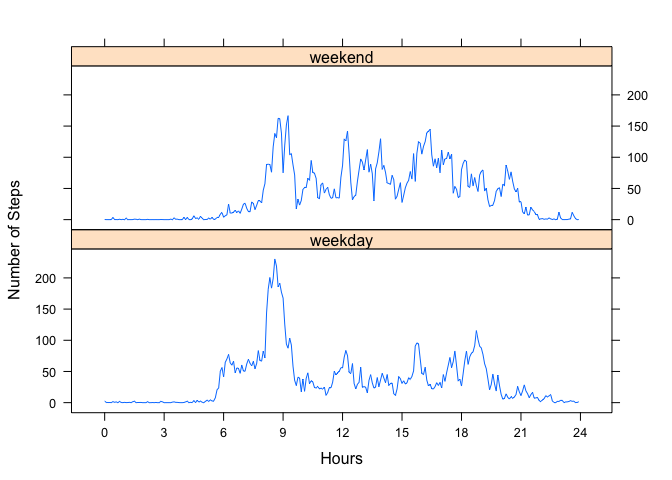

```r
library(lattice)
xyplot(steps ~ as.numeric(interval)/3600 | weekdays, data = act.modified,
      type = 'l', xlab = 'Hours', ylab = 'Number of Steps', layout = c(1,2),
      scales=list(x=list(at=seq(0,24,3))))
```

All plots are stored in **./figures/**.